# EU-ForDAM: correlation metrics, insect vs insect

Do the existing records carry information about the missing ones?

Published

October 21, 2026

## Why these metrics

The thesis rests on one sentence: *damage from different agents tends to fluctuate together, so the existing records carry information about the missing ones.* The correlation metrics test that sentence, pair by pair, for all 43 single insects (903 pairs). Groups follow Table 1 of the 2025 EU-ForDAM paper (`data/lookup/paper_hierarchy_2025.csv`). Aggregate reporting codes (several insects lumped together, e.g. “borers on pine”) are left out here, because comparing a group with its own members says nothing new; they are used in the group-level correlations at the end. Each question below serves one objective:

| Question | Metric | Objective |
| --- | --- | --- |
| 1. Does insect A have bad years when insect B does, in the same region? | same-year r, within region | the premise |
| 2. Does that link hold in every country? | r per country | 1, gap-filling (links learnt in one country fill gaps in another) |
| 3. Is the link regional or Europe-wide? Does one come first? | r of the regional part; A this year vs B next year | 3, drivers and anticipation |
| 4. Do linked insects share feeding type or host tree? | share of strong links within vs between groups | 2, damage across agents and host trees |

**How r is measured.** `value1` only (`value2` is the same damage in another unit). 0 = monitored, no damage; not reported = unknown, left out. Damage on a log(1 + x) scale, each region’s series compared with its own average, so a large and a small region count the same. Only region-years where both insects were recorded. The 95% range comes from resampling whole regions 999 times; a link is *sure* when the range excludes 0, *strong* when also r ≥ 0.3. As in the 2025 EU-ForDAM paper, the spruce bark-borer group of Czechia and Germany is counted as *I. typographus*.

## The heatmap: every insect against every other

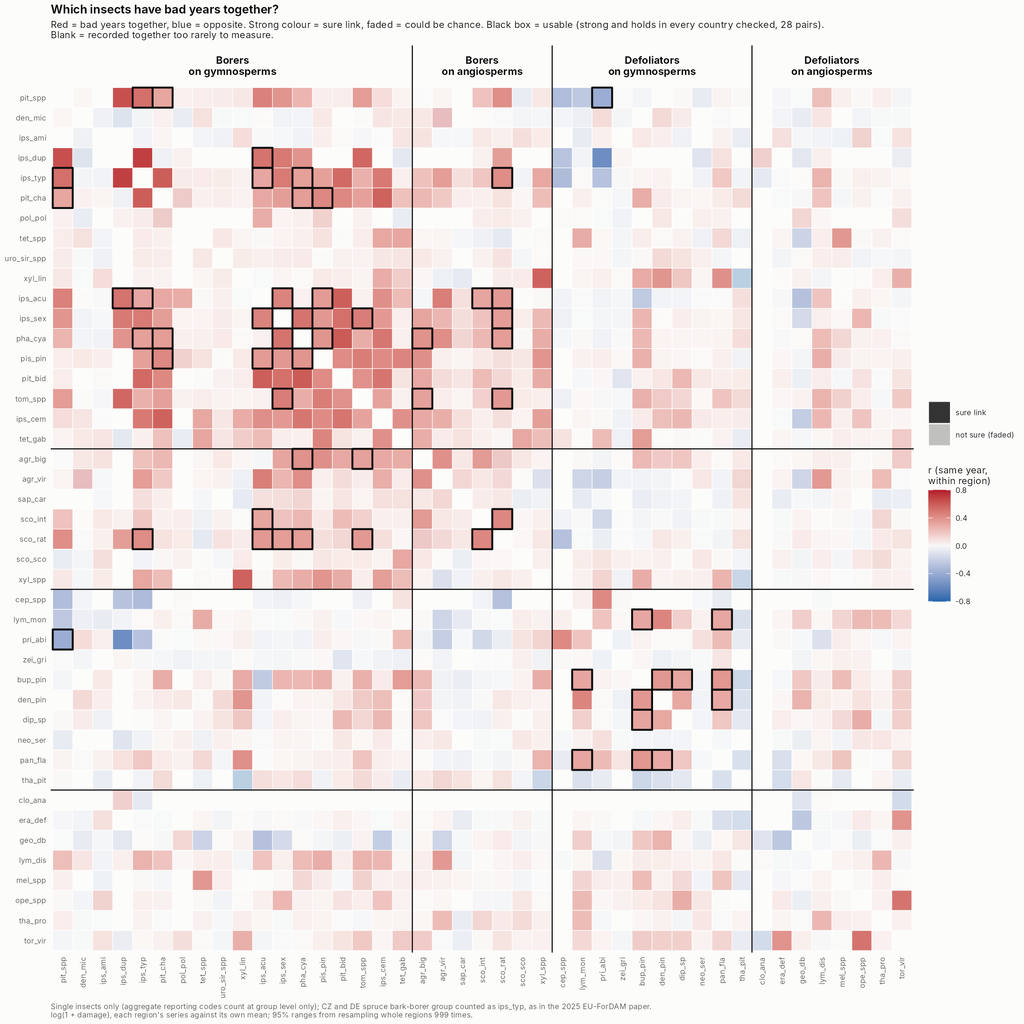

How to read it: each square is one pair of insects. **Red** = they have bad years together, **blue** = one is high when the other is low; the darker, the stronger. **Strong colour** = a sure link; **faded** = the 95% range includes 0, so it could be chance. **Black boxes** are the usable links (strong and the same in every country checked). Blank = recorded together too rarely to measure. Lines split the paper’s four level-1 groups. The red block in the top left is the borers on gymnosperms (bark and wood borers on spruce, pine and fir): that is where most of the shared signal sits.

## The answer in one figure

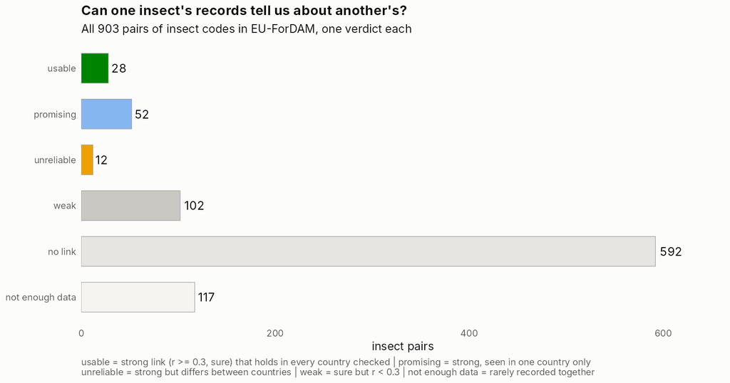

| verdict | pairs | share | meaning |
| --- | --- | --- | --- |
| usable | 28 | 3% | strong, and holds in every country checked: lean on it |
| promising | 52 | 6% | strong, but only seen in one country: cannot check yet |
| unreliable | 12 | 1% | strong, but differs between countries: do not transfer |
| weak | 102 | 11% | sure but small (r < 0.3) |
| no link | 592 | 66% | no detectable link |
| not enough data | 117 | 13% | recorded together too rarely to measure |

## 1 and 2: the links we can use

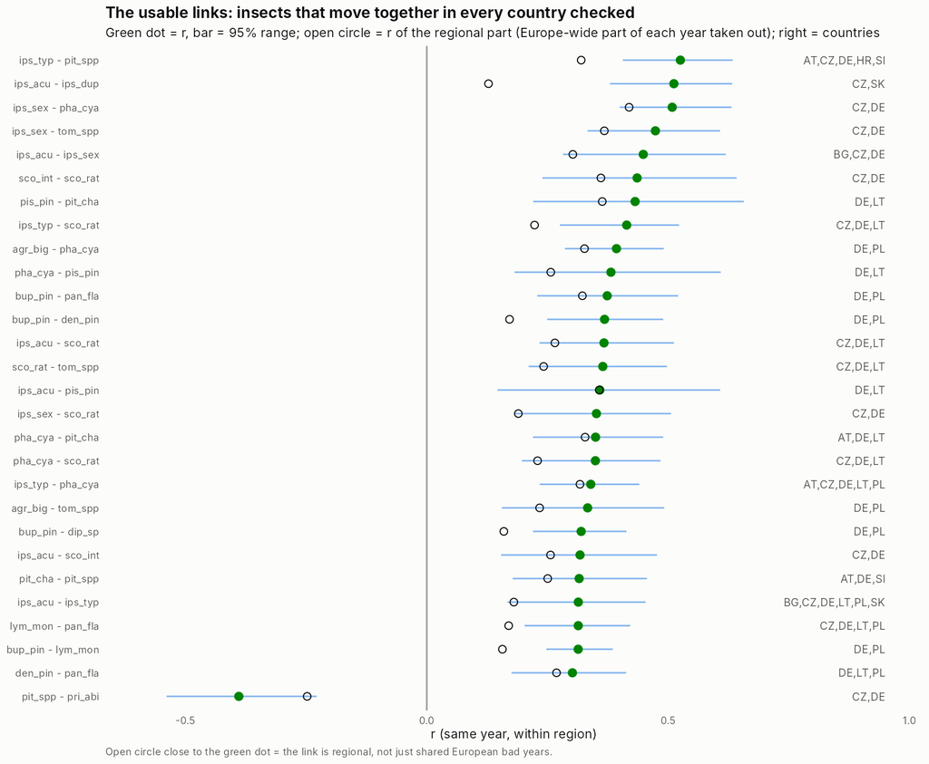

- **28 pairs are usable**: strong, and the same direction and similar size in every country where they are recorded together. These are what gap-filling can lean on.
- 52 more are strong but seen in one country only; they may be real but cannot be checked yet. 12 are strong in one place and not in another.
- Almost all are positive (bad years together). One clear negative: *Pityokteines* spp. with *Pristiphora abietina*.

## 4: feeding type matters, host tree adds little

| pair | measurable pairs | strong links | share strong | usable |
| --- | --- | --- | --- | --- |
| different broad groups | 564 | 31 | 5% | 9 |
| same broad group | 222 | 61 | 27% | 19 |

## 5: does a link predict a country it has never seen?

The correlation tells us two insects move together where both are recorded. Gap-filling needs more: a link learnt in some countries must work in a country that never reported one of the insects. So we test exactly that.

**How.** For each pair (A, B) and each country where both are recorded: hide that country, learn how B follows A in the other countries, then guess B’s ups and downs in the hidden country from A alone. Compare with the simplest guess, “a normal year”. **Skill** = how much smaller the error is: 0 = no help, 0.1 = 10% smaller error, below 0 = the link learnt elsewhere misleads. Both directions (A → B and B → A) are pooled.

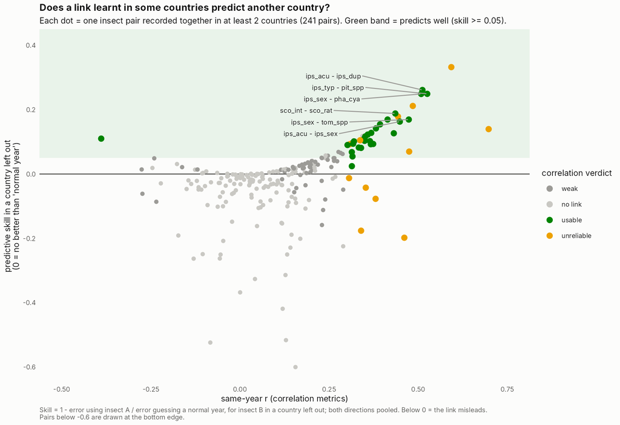

| predictive | pairs | meaning |
| --- | --- | --- |
| predicts well | 32 | skill >= 0.05 and helps in at least 3 of 4 hidden countries |
| predicts a little | 78 | skill > 0 and helps in at least half |
| no help | 75 | about as good as guessing a normal year |
| misleads | 56 | skill < -0.05: the link does not transfer and makes guesses worse |
| cannot test | 662 | recorded together in fewer than 2 countries |

| verdict | predicts well | predicts a little | no help | misleads |
| --- | --- | --- | --- | --- |
| usable | 20 | 8 | 0 | 0 |
| unreliable | 2 | 5 | 2 | 3 |

- **The correlation verdicts hold up.** All 28 usable pairs help predict a country left out: 20 predict well, 8 a little, none mislead. Of the 12 unreliable pairs, 3 make guesses worse, which is exactly why they were flagged.
- **The gain from one partner insect is modest.** For usable pairs the error is typically 11% smaller (range 2-26%), and still 8% in the regional part. The best: *I. acuminatus* with *I. duplicatus*, *I. typographus* with *Pityokteines*, *I. sexdentatus* with *Phaenops cyanea* (about 25%).
- **High correlation is not enough.** *I. typographus* with *Pityogenes chalcographus* has the highest pooled r and a high pooled skill, but the link differs between countries (strong in DE and AT, not in IT or SK), so it is “unreliable”.
- **Most pairs cannot be tested** (662 of 903): they are recorded together in only one country.

For gap-filling this means: one partner insect gives a modest but real gain, so the factor model, which combines all partners at once, is the right tool. The usable links are the ones it can trust across countries.

## Check: does the choice of correlation matter? (Spearman)

Pearson r uses the actual sizes of the ups and downs, so one huge outbreak year can dominate a series. Spearman r uses only the **order** of the years (which year was a region’s worst, second worst, …), so outbreaks cannot dominate. We reran the whole pipeline with within-region ranks instead of values.

- The two agree almost perfectly: correlation between Pearson and Spearman r across all pairs = 0.97; typical difference 0.02.
- Usable pairs: 28 with Pearson, 29 with Spearman, 22 in both. The pairs that switch sit right at the edges (r near 0.3, or consistent in one country check but not the other).
- So the results are **not** driven by a few extreme outbreak years. Pearson stays the main metric; Spearman is the robustness check (`outputs/tables/CM_pearson_vs_spearman.csv`).

## The paper’s groups (levels 1 and 2)

Group value in a region-year = sum of all recorded member codes, **aggregates included**. Same metric as above (within region, 95% range from resampling regions), plus the paper’s own approach (Pearson r of the Europe-wide yearly totals).

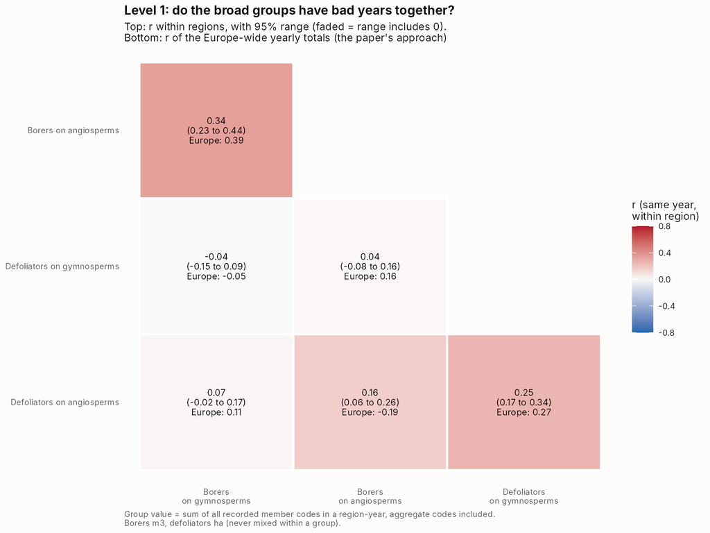

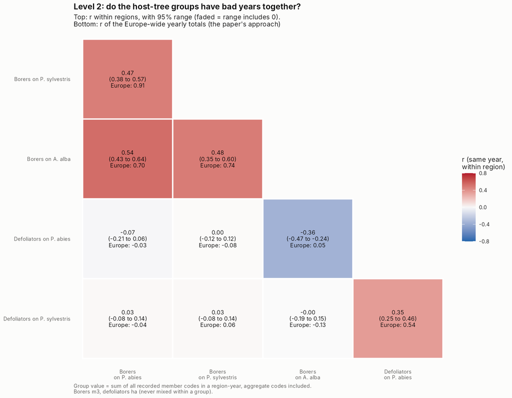

| level | group A | group B | region-years | r within region | 95% range | r Europe totals |
| --- | --- | --- | --- | --- | --- | --- |
| level1 | Borers on angiosperms | Borers on gymnosperms | 800 | 0.34 | 0.23 to 0.44 | 0.39 |
| level1 | Borers on angiosperms | Defoliators on angiosperms | 800 | 0.16 | 0.06 to 0.26 | -0.19 |
| level1 | Borers on angiosperms | Defoliators on gymnosperms | 757 | 0.04 | -0.08 to 0.16 | 0.16 |
| level1 | Borers on gymnosperms | Defoliators on angiosperms | 1098 | 0.07 | -0.02 to 0.17 | 0.11 |
| level1 | Borers on gymnosperms | Defoliators on gymnosperms | 926 | -0.04 | -0.15 to 0.09 | -0.05 |
| level1 | Defoliators on angiosperms | Defoliators on gymnosperms | 905 | 0.25 | 0.17 to 0.34 | 0.27 |
| level2 | Borers on A. alba | Borers on P. abies | 469 | 0.54 | 0.43 to 0.64 | 0.70 |
| level2 | Borers on A. alba | Borers on P. sylvestris | 448 | 0.48 | 0.35 to 0.60 | 0.74 |
| level2 | Borers on A. alba | Defoliators on P. abies | 253 | -0.36 | -0.47 to -0.24 | 0.05 |
| level2 | Borers on A. alba | Defoliators on P. sylvestris | 245 | -0.00 | -0.19 to 0.15 | -0.13 |
| level2 | Borers on P. abies | Borers on P. sylvestris | 1054 | 0.47 | 0.38 to 0.57 | 0.91 |
| level2 | Borers on P. abies | Defoliators on P. abies | 734 | -0.07 | -0.21 to 0.06 | -0.03 |
| level2 | Borers on P. abies | Defoliators on P. sylvestris | 765 | 0.03 | -0.08 to 0.14 | -0.04 |
| level2 | Borers on P. sylvestris | Defoliators on P. abies | 734 | 0.00 | -0.12 to 0.12 | -0.08 |
| level2 | Borers on P. sylvestris | Defoliators on P. sylvestris | 765 | 0.03 | -0.08 to 0.14 | 0.06 |
| level2 | Defoliators on P. abies | Defoliators on P. sylvestris | 619 | 0.35 | 0.25 to 0.46 | 0.54 |

- Borers on spruce, pine and fir have bad years together; so do spruce and pine defoliators.
- Borers and defoliators do not move together; borers on fir go **against** defoliators on spruce (the group version of the *Pityokteines* x *Pristiphora* link).
- Europe-wide totals give much higher r than within-region series, because a Europe-wide total mixes regional signals with shared bad years; the within-region number is the one that matters for gap-filling.

## What it means for the thesis

1. **The premise holds for a core of insects, not for all.** About 12% of measurable pairs are strongly linked, mostly within feeding groups. For those insects, the records of one do carry information about the other.
2. **Gap-filling (objective 1)** should lean on the 28 usable links and treat the rest with caution. The factor model does this automatically: it learns the shared patterns from all insects at once.
3. **Drivers and anticipation (objective 3):** most links are regional, not Europe-wide, and some insects lead others by a year. Both point to regional drivers worth testing once the drought and storm data are in.
4. **Limit:** many links can only be seen in one or two countries (mostly DE and CZ). More countries reporting more insects is what would firm this up.

## Files

- One row per pair, plain verdict: `outputs/tables/CM_pairs_verdict.csv`
- Predictive test: `CM_predictive_pairs.csv` (per pair), `CM_predictive_by_country.csv` (per hidden country)
- Full detail (ranges, per-country r): `CM_basic_all_pairs.csv`, `CM_basic_Q4_per_country.csv`, `CM_basic_Q3_lead_effects.csv`
- Groups: `CM_groups_level1_level2.csv`
- Figures: `outputs/figures/CM_heatmap.png`, `CM_verdict.png`, `CM_usable_pairs.png`, `CM_groups_level1.png`, `CM_groups_level2.png`